# Analisi della relazione tra inflazione e variabili economiche (WIP)

## Introduzione

Questo progetto analizza la relazione tra l'inflazione e altre variabili economiche, quali la crescita del reddito disponibile (DPI) e l'espansione della massa monetaria (broad money). L'ispirazione è un proseguimento della mia tesi di laurea, che lasciava aperto all'analisi di possibli relazioni tra masse monetarie e disequilibri tra il reddito disponile e la crescita del pil. Questo progetto è quindi l'occasione per soddisfare la richetsa di saper utilizzare linguiggi di programamzione come python per fare delle analisi e la curiosità peosnale di esplorare un tema che susicita interesse personale da svariato tempo.

## Obiettivo

L'obiettivo è costruire un modello di regressione lineare che preveda l'inflazione basandosi sui ritardi delle variabili economiche selezionate.

## Dataset

- **Inflation**: tasso di inflazione.
- **Excess DPI GDP Growth**: crescita del DPI in eccesso rispetto al PIL. Data dalla diffrenza della crescita reale del DPI e delle crecita reale del PIL (in percentuale come l'inflaizone è misurata)
- **Excess Broad Money**: crescita della massa monetaria. Definita dal paper di Borio "**The two-regime view of inflation**", come la differenza della crescita di M2 o M3 e la crescita reale del PI (in percentuale).

## Caricamento dei Dati e Creazione di Variabili con ritardo

Vengono poi create delle variabili ritardate (lag) per analizzare l'effetto delle variabili economiche passate:

- **Crescita del reddito disponibile rispetto al PIL** (`excess_dpi_gdp_growth`), con ritardi di 1, 2 e 3 periodi.
- **Inflazione** (`inflation`), con ritardi di 1, 2 e 3 periodi.
- **Crescita della massa monetaria** (`excess_broad_money`), con ritardi di 1, 2 e 3 periodi.

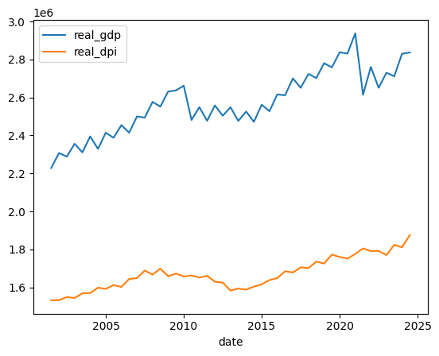

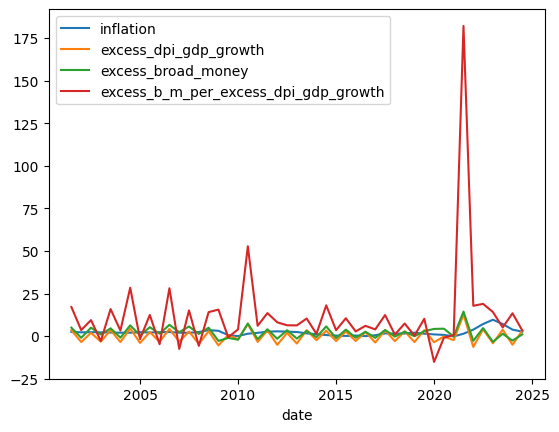

```python
import pandas as pd
import matplotlib.pyplot as plt
from sklearn.linear_model import LinearRegression # type: ignore
import numpy as np
import statsmodels.api as sm

eu_2000_2025=pd.read_excel("eu_bm_var_incr.xlsx",index_col=0)#,parse_dates = True)

eu_2000_2025["excess_dpi_gdp_growth_lag1"]=eu_2000_2025["excess_dpi_gdp_growth"].shift(1)
eu_2000_2025["excess_dpi_gdp_growth_lag2"]=eu_2000_2025["excess_dpi_gdp_growth"].shift(2)
eu_2000_2025["excess_dpi_gdp_growth_lag3"]=eu_2000_2025["excess_dpi_gdp_growth"].shift(3)

eu_2000_2025["inflation_lag1"]=eu_2000_2025["inflation"].shift(1)
eu_2000_2025["inflation_lag2"]=eu_2000_2025["inflation"].shift(2)
eu_2000_2025["inflation_lag3"]=eu_2000_2025["inflation"].shift(3)

eu_2000_2025["excess_broad_money_lag1"]=eu_2000_2025["excess_broad_money"].shift(1)
eu_2000_2025["excess_broad_money_lag2"]=eu_2000_2025["excess_broad_money"].shift(2)
eu_2000_2025["excess_broad_money_lag3"]=eu_2000_2025["excess_broad_money"].shift(3)

#eu_bm_var_incr

eu_2000_2025["excess_b_m_per_excess_dpi_gdp_growth_lag1"]=eu_2000_2025["excess_b_m_per_excess_dpi_gdp_growth"].shift(1)
eu_2000_2025["excess_b_m_per_excess_dpi_gdp_growth_lag2"]=eu_2000_2025["excess_b_m_per_excess_dpi_gdp_growth"].shift(2)
eu_2000_2025["excess_b_m_per_excess_dpi_gdp_growth_lag3"]=eu_2000_2025["excess_b_m_per_excess_dpi_gdp_growth"].shift(3)



eu_2000_2025 = eu_2000_2025.dropna()

eu_2000_2025.head()

#print(eu_2000_2025["excess_b_m_per_excess_dpi_gdp_growth"])
new=eu_2000_2025["excess_b_m_per_excess_dpi_gdp_growth"].copy().to_numpy()

eu_2000_2025[["real_gdp","real_dpi"]].plot()
eu_2000_2025[["inflation","excess_dpi_gdp_growth","excess_broad_money","excess_b_m_per_excess_dpi_gdp_growth"]].plot()
```

## Creazione del Modello di Regressione Lineare

In questo blocco, viene costruito un modello di regressione lineare per analizzare la relazione tra l'inflazione attuale e le variabili ritardate (lag) di inflazione, crescita del reddito disponibile rispetto al PIL, e crescita della massa monetaria.

- **Variabile dipendente (y)**: L'inflazione attuale (`inflation`).
- **Variabili indipendenti (X)**: Le variabili ritardate di inflazione, crescita del reddito disponibile rispetto al PIL e crescita della massa monetaria, tutte con ritardi da 1 a 3 periodi.

Il modello di regressione lineare viene creato e vengono effettuate delle previsioni utilizzando il metodo `.predict()`, e i risultati vengono memorizzati in una nuova colonna chiamata `predictions`. Viene realizzata una visualizzazione che confronta l'inflazione reale con le previsioni del modello.

```
Coefficiente: [ 1.07574621 -0.75125573  0.34710631  0.04984179  0.00828463 -0.13431726
  0.02557924  0.01633137  0.13031042  0.00148771  0.02170161  0.01914004]
Intercetta: -0.12129519145905165
Previsioni: [1.67744143 1.86444801 2.07918777 2.34102729 1.84413238 2.09018446
 1.96845691 2.14162785 2.52233837 2.06853965 2.37291035 2.37622037
 2.20973467 2.22988222 2.55986288 3.30954039 2.17316816 0.18930686
 0.99970153 2.01485938 2.03994263 3.11846687 2.03960714 2.1004828
 2.0809297  1.3608438  1.38166425 0.70004335 0.74354277 0.91338914
 0.68154473 0.22710046 0.81939287 1.67347461 1.0040238  1.44922452
 1.81703505 0.74961964 1.26368573 0.27259188 0.15050425 3.61687556
 7.07195006 9.44618712 7.2701653  3.65150809 2.22363293]
```

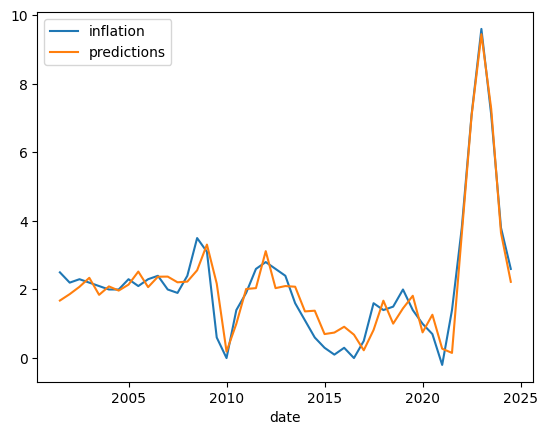

```python
y = eu_2000_2025['inflation']
X = eu_2000_2025[['inflation_lag1', 'inflation_lag2','inflation_lag3','excess_dpi_gdp_growth_lag1','excess_dpi_gdp_growth_lag2','excess_dpi_gdp_growth_lag3','excess_broad_money_lag1','excess_broad_money_lag2','excess_broad_money_lag3','excess_b_m_per_excess_dpi_gdp_growth_lag1','excess_b_m_per_excess_dpi_gdp_growth_lag2','excess_b_m_per_excess_dpi_gdp_growth_lag3']]

# Cre1azione del modello
reg = LinearRegression()
reg.fit(X, y)

# Coefficienti e intercetta
print("Coefficiente:", reg.coef_)
print("Intercetta:", reg.intercept_)

# Previsioni
predictions = reg.predict(X)
print("Previsioni:", predictions)

eu_2000_2025['predictions']=predictions

eu_2000_2025[['inflation','predictions']].plot()
```

## Simulazione dell'Inflazione tramite il Modello di Regressione

In questo blocco di codice, viene effettuata una simulazione dell'inflazione utilizzando il modello di regressione precedentemente creato. L'obiettivo è prevedere l'inflazione futura partendo dai valori attuali e dalle variabili ritardate.

1. **Preparazione dei Dati**: Viene creato un DataFrame `testing` contenente i dati necessari. Vengono poi rimosse alcune colonne non utilizzate per la simulazione, come le variabili originali di inflazione e crescita economica.
2. **Inizializzazione della Simulazione**: La variabile `simulated_inflation` viene inizializzata con i valori di inflazione attuali. Per simulare l'inflazione futura, i valori a partire dall'indice `t+1` vengono impostati inizialmente a zero.
3. **Simulazione Iterativa**: La simulazione procede iterativamente, utilizzando il modello di regressione per calcolare il valore dell'inflazione al periodo `t+1` basato sui valori correnti di inflazione, crescita del reddito disponibile rispetto al PIL e crescita della massa monetaria.
   - I coefficienti del modello vengono utilizzati per pesare l'influenza delle variabili di inflazione e delle variabili lag.
   - Il ciclo continua fino a che tutte le previsioni future dell'inflazione non sono state simulate.
4. **Visualizzazione**: Dopo la simulazione, la colonna `simulated_inflation` viene aggiornata con i valori previsti, e viene realizzata una visualizzazione per confrontare l'inflazione reale con quella simulata.

Questo approccio consente di simulare l'andamento futuro dell'inflazione in base ai dati storici e alle previsioni del modello.

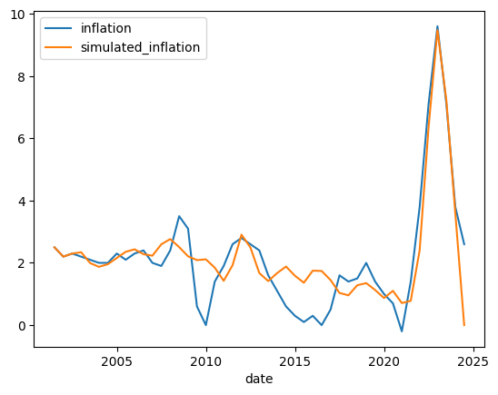

```python
testing=eu_2000_2025

columns_to_drop = [
    'hicp', 'gdp', 'real_gdp', 'real_growth_gdp', 'dpi',
    'real_growth_dpi', 'real_dpi_over_real_gdp', 'real_dpi',
    'real_dpi_over_real_gdp_growth', 'excess_dpi_gdp_growth_lag1',
    'excess_dpi_gdp_growth_lag2', 'excess_dpi_gdp_growth_lag3',
    'excess_broad_money_lag1', 'excess_broad_money_lag2',
    'excess_broad_money_lag3', 'predictions','excess_b_m_per_excess_dpi_gdp_growth_lag1','excess_b_m_per_excess_dpi_gdp_growth_lag2','excess_b_m_per_excess_dpi_gdp_growth_lag3'
]

testing = testing.drop(columns=columns_to_drop)
testing["simulated_inflation"]=testing["inflation"]

simulated_inflation=testing["simulated_inflation"].to_numpy()
excess_growth_dpi=testing["excess_dpi_gdp_growth"].to_numpy()
excess_broad_money=testing["excess_broad_money"].to_numpy()
excess_b_m_per_excess_dpi_gdp_growth=testing["excess_b_m_per_excess_dpi_gdp_growth"].to_numpy()

t=2#23 #indice del 2013
simulated_inflation[t+1:]=0
while t<simulated_inflation.size-2:

    coef_0_2_inflation=reg.coef_[0]*simulated_inflation[t]+reg.coef_[1]*simulated_inflation[t-1]+reg.coef_[2]*simulated_inflation[t-2]
    coef_3_5_excess_growth_dpi=reg.coef_[3]*excess_growth_dpi[t]+reg.coef_[4]*excess_growth_dpi[t-1]+reg.coef_[5]*excess_growth_dpi[t-2]
    coef_6_8_excess_broad_money=reg.coef_[6]*excess_broad_money[t]+reg.coef_[7]*excess_broad_money[t-1]+reg.coef_[8]*excess_broad_money[t-2]
    coef_9_11_excess_b_m_per_excess_dpi_gdp_growth=reg.coef_[9]*excess_b_m_per_excess_dpi_gdp_growth[t]+reg.coef_[10]*excess_b_m_per_excess_dpi_gdp_growth[t-1]+reg.coef_[11]*excess_b_m_per_excess_dpi_gdp_growth[t-2]

    simulated_inflation[t+1] = reg.intercept_ +  coef_0_2_inflation+coef_3_5_excess_growth_dpi+coef_6_8_excess_broad_money+coef_9_11_excess_b_m_per_excess_dpi_gdp_growth
    t=t+1

testing["simulated_inflation"]=simulated_inflation


testing[["inflation","simulated_inflation"]].plot()
```

## Analisi della Relazione tra Inflazione Simulata e Inflazione Reale

In questo blocco di codice, viene eseguita un'analisi della relazione tra l'inflazione simulata (derivata dal modello precedente) e l'inflazione reale, utilizzando un modello di regressione lineare.

1. **Scatter Plot**: Viene creato un grafico a dispersione (scatter plot) che confronta i valori di inflazione simulata (`simulated_inflation`) e inflazione reale (`inflation`). Questo permette di visualizzare visivamente la correlazione tra le due variabili.
2. **Modello di Regressione**: Viene costruito un nuovo modello di regressione lineare per stimare l'inflazione reale in base all'inflazione simulata.
   - La variabile dipendente è l'inflazione reale (`inflation`).
   - La variabile indipendente è l'inflazione simulata (`simulated_inflation`).
3. **Coefficiente e Intercetta**: Il modello viene addestrato utilizzando il metodo `.fit()`, e vengono quindi stampati i coefficienti e l'intercetta del modello, che rappresentano la relazione tra inflazione simulata e inflazione reale.
4. **Valutazione del Modello**: Viene calcolato il valore di ( R^2 ), che indica la bontà dell'adattamento del modello ai dati. Un valore più alto di ( R^2 ) suggerisce che il modello spiega bene la variabilità dei dati.
5. **Previsioni e Visualizzazione**: Le previsioni basate sull'inflazione simulata vengono calcolate e tracciate, mostrando come il modello prevede l'inflazione reale in base ai valori simulati.

Questo blocco fornisce un'analisi della capacità predittiva dell'inflazione simulata rispetto all'inflazione reale, usando un semplice modello di regressione lineare.

```
Coefficiente: [1.00498955]
Intercetta: -0.0835950411217734
R^2; 0.7843349721945914
Previsioni: [ 2.42887883  2.12738196  2.22788092  2.26911292  1.92220526  1.79793562
  1.88434112  2.08365436  2.28317721  2.36473086  2.20576643  2.15873268
  2.52672889  2.6942302   2.43673926  2.13822074  2.01516159  2.0409689
  1.77269353  1.34775172  1.85208375  2.8369915   2.42373827  1.59853815
  1.33896239  1.59619723  1.80873776  1.51113135  1.28556555  1.67510109
  1.6647257   1.37101914  0.95649217  0.87888541  1.20438573  1.2735469
  1.05083192  0.79081777  1.02408565  0.62865044  0.70110572  2.33612366
  6.30289944  9.43925359  7.16527529  3.54215647 -0.08359504]
```

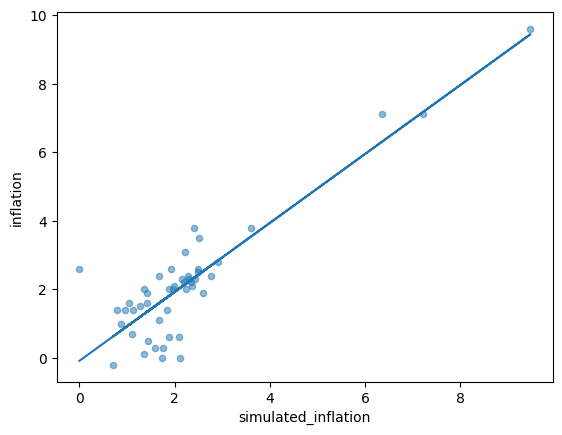

```python
testing.plot.scatter(x = "simulated_inflation", y = "inflation", alpha = 0.5)
y_infl = testing['inflation']

# Variabili indipendenti (ritardi)
X_infl = testing[['simulated_inflation']]

# Creazione del modello
reg_infl = LinearRegression().fit(X_infl, y_infl)

# Coefficienti e intercetta
print("Coefficiente:", reg_infl.coef_)
print("Intercetta:", reg_infl.intercept_)
print("R^2;",reg_infl.score(X_infl,y_infl))

# Previsioni
predictions_infl = reg_infl.predict(X_infl)
print("Previsioni:", predictions_infl)

plt.plot(X_infl,predictions_infl)
```

## Creazione e Valutazione del Modello OLS (Ordinary Least Squares)

In questo blocco, viene costruito e valutato un modello di regressione lineare usando il metodo OLS, per analizzare la relazione tra inflazione e variabili indipendenti, tenendo conto dell'intercetta.

1. **Aggiunta dell'Intercetta**: Una colonna costante viene aggiunta al DataFrame delle variabili indipendenti (`X`) per includere l'intercetta nel modello di regressione. Questo passaggio è fondamentale per il corretto calcolo dei parametri del modello.
2. **Creazione del Modello OLS**: Viene creato un modello di regressione lineare utilizzando il metodo `sm.OLS()` della libreria `statsmodels`. Il modello viene addestrato sui dati con il metodo `.fit()`. I risultati vengono stampati tramite `summary()`, che fornisce un'analisi approfondita dei parametri del modello, come i coefficienti, i valori di ( p ), e l'R-quadrato.
3. **Selezione delle Variabili Significative**: Le variabili significative vengono identificate sulla base dei valori di ( p ) (p-value) ottenuti dal modello. Le variabili con ( p )-value inferiore a 0.05 vengono selezionate per il modello ridotto, che include solo le variabili statisticamente significative.
4. **Aggiornamento delle Previsioni**: Le previsioni vengono calcolate utilizzando il modello ridotto e vengono aggiunte al DataFrame come una nuova colonna (`updated_predictions`).
5. **Intervalli di Confidenza**: Vengono calcolati gli intervalli di confidenza per le previsioni utilizzando il metodo `get_prediction()`, e vengono aggiunti al DataFrame come colonne `lower_ci` e `upper_ci`, che rappresentano rispettivamente i limiti inferiore e superiore degli intervalli di confidenza al 95%.
6. **Visualizzazione**: Viene creato un grafico che mostra l'inflazione osservata e quella predetta dal modello aggiornato. Viene anche visualizzato l'intervallo di confidenza, che indica l'incertezza associata alle previsioni del modello.

Questo blocco fornisce una valutazione dettagliata delle previsioni del modello OLS, mettendo in evidenza le variabili significative e visualizzando i risultati con gli intervalli di confidenza.

```
                            OLS Regression Results
==============================================================================
Dep. Variable:              inflation   R-squared:                       0.922
Model:                            OLS   Adj. R-squared:                  0.895
Method:                 Least Squares   F-statistic:                     33.54
Date:                Sun, 15 Dec 2024   Prob (F-statistic):           2.58e-15
Time:                        15:10:30   Log-Likelihood:                -34.822
No. Observations:                  47   AIC:                             95.64
Df Residuals:                      34   BIC:                             119.7
Df Model:                          12
Covariance Type:            nonrobust
=============================================================================================================
                                                coef    std err          t      P>|t|      [0.025      0.975]
-------------------------------------------------------------------------------------------------------------
const                                        -0.1213      0.271     -0.447      0.658      -0.673       0.430
inflation_lag1                                1.0757      0.182      5.921      0.000       0.707       1.445
inflation_lag2                               -0.7513      0.266     -2.822      0.008      -1.292      -0.210
inflation_lag3                                0.3471      0.172      2.015      0.052      -0.003       0.697
excess_dpi_gdp_growth_lag1                    0.0498      0.106      0.472      0.640      -0.165       0.265
excess_dpi_gdp_growth_lag2                    0.0083      0.102      0.081      0.936      -0.200       0.216
excess_dpi_gdp_growth_lag3                   -0.1343      0.091     -1.475      0.149      -0.319       0.051
excess_broad_money_lag1                       0.0256      0.071      0.359      0.722      -0.119       0.170
excess_broad_money_lag2                       0.0163      0.074      0.221      0.826      -0.134       0.166
excess_broad_money_lag3                       0.1303      0.066      1.965      0.058      -0.004       0.265
excess_b_m_per_excess_dpi_gdp_growth_lag1     0.0015      0.007      0.208      0.836      -0.013       0.016
excess_b_m_per_excess_dpi_gdp_growth_lag2     0.0217      0.007      3.053      0.004       0.007       0.036
excess_b_m_per_excess_dpi_gdp_growth_lag3     0.0191      0.008      2.361      0.024       0.003       0.036
==============================================================================
Omnibus:                        2.475   Durbin-Watson:                   1.712
Prob(Omnibus):                  0.290   Jarque-Bera (JB):                1.573
Skew:                          -0.201   Prob(JB):                        0.455
Kurtosis:                       3.801   Cond. No.                         139.
==============================================================================

Notes:
[1] Standard Errors assume that the covariance matrix of the errors is correctly specified.
                                 OLS Regression Results
=======================================================================================
Dep. Variable:              inflation   R-squared (uncentered):                   0.933
Model:                            OLS   Adj. R-squared (uncentered):              0.927
```

[output cut: 9 more lines]

```
-------------------------------------------------------------------------------------------------------------
inflation_lag1                                1.0462      0.128      8.201      0.000       0.789       1.303
inflation_lag2                               -0.3497      0.111     -3.152      0.003      -0.573      -0.126
excess_b_m_per_excess_dpi_gdp_growth_lag2     0.0194      0.004      4.444      0.000       0.011       0.028
excess_b_m_per_excess_dpi_gdp_growth_lag3     0.0173      0.005      3.571      0.001       0.008       0.027
==============================================================================
Omnibus:                        7.929   Durbin-Watson:                   1.369
Prob(Omnibus):                  0.019   Jarque-Bera (JB):                8.993
Skew:                           0.558   Prob(JB):                       0.0111
Kurtosis:                       4.829   Cond. No.                         46.8
==============================================================================

Notes:
[1] R² is computed without centering (uncentered) since the model does not contain a constant.
[2] Standard Errors assume that the covariance matrix of the errors is correctly specified.
```

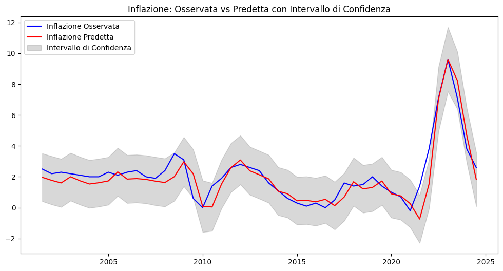

```python
# Aggiunta di una colonna costante per l'intercetta
X_const = sm.add_constant(X)

# Creazione del modello OLS (Ordinary Least Squares)
model = sm.OLS(y, X_const)
results = model.fit()

# Risultati
print(results.summary())

p_values = results.pvalues
significant_vars = p_values[p_values < 0.05].index
X_significant = X_const[significant_vars]
model_significant = sm.OLS(y, X_significant).fit()
print(model_significant.summary())


updated_predictions = model_significant.predict(X_significant)
eu_2000_2025['updated_predictions'] = updated_predictions

#eu_2000_2025[['inflation', 'updated_predictions']].plot(title="Inflazione: Osservata vs Prevista (Modello Aggiornato)")
predictions = model_significant.get_prediction(X_significant)
pred_summary = predictions.summary_frame(alpha=0.05)

# Aggiungere previsioni al dataframe
eu_2000_2025['lower_ci'] = pred_summary['obs_ci_lower']
eu_2000_2025['upper_ci'] = pred_summary['obs_ci_upper']

# Plot delle previsioni con intervalli
plt.figure(figsize=(12, 6))
plt.plot(eu_2000_2025.index, eu_2000_2025['inflation'], label='Inflazione Osservata', color='blue')
plt.plot(eu_2000_2025.index, eu_2000_2025['updated_predictions'], label='Inflazione Predetta', color='red')
plt.fill_between(eu_2000_2025.index, eu_2000_2025['lower_ci'], eu_2000_2025['upper_ci'],
                 color='gray', alpha=0.3, label='Intervallo di Confidenza')
plt.title("Inflazione: Osservata vs Predetta con Intervallo di Confidenza")
plt.legend()
plt.show()
```

## Simulazione dell'Inflazione con Variabili Significative

Questo blocco di codice fornisce un'analisi avanzata dell'inflazione simulata, considerando solo le variabili che si sono rivelate statisticamente significative nel modello precedente.

```
        inflation_lag1  inflation_lag2  \
date
2001.5             2.3             1.9
2002.0             2.5             2.3
2002.5             2.2             2.5
2003.0             2.3             2.2
2003.5             2.2             2.3
2004.0             2.1             2.2
2004.5             2.0             2.1
2005.0             2.0             2.0
2005.5             2.3             2.0
2006.0             2.1             2.3
2006.5             2.3             2.1
2007.0             2.4             2.3
2007.5             2.0             2.4
2008.0             1.9             2.0
2008.5             2.4             1.9
2009.0             3.5             2.4
2009.5             3.1             3.5
2010.0             0.6             3.1
2010.5             0.0             0.6
2011.0             1.4             0.0
2011.5             1.9             1.4
2012.0             2.6             1.9
2012.5             2.8             2.6
2013.0             2.6             2.8
2013.5             2.4             2.6
2014.0             1.6             2.4
2014.5             1.1             1.6
2015.0             0.6             1.1
2015.5             0.3             0.6
2016.0             0.1             0.3
2016.5             0.3             0.1
2017.0             0.0             0.3
2017.5             0.5             0.0
2018.0             1.6             0.5
2018.5             1.4             1.6
2019.0             1.5             1.4
2019.5             2.0             1.5
2020.0             1.4             2.0
```

[output cut: 97 more lines]

```
2019.0                                  12.362171
2019.5                                   0.897788
2020.0                                   7.369308
2020.5                                   0.273985
2021.0                                  10.173814
2021.5                                 -15.161131
2022.0                                  -0.977151
2022.5                                   0.627256
2023.0                                 182.087906
2023.5                                  17.781766
2024.0                                  18.925064
2024.5                                  14.156356
[2.5 2.2 2.3 0.  0.  0.  0.  0.  0.  0.  0.  0.  0.  0.  0.  0.  0.  0.
 0.  0.  0.  0.  0.  0.  0.  0.  0.  0.  0.  0.  0.  0.  0.  0.  0.  0.
 0.  0.  0.  0.  0.  0.  0.  0.  0.  0.  0. ]
```

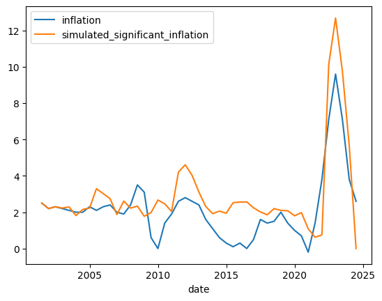

```python
simulated_significant_inflation = eu_2000_2025['inflation'].copy().to_numpy()
excess_growth_dpi = eu_2000_2025['excess_dpi_gdp_growth'].to_numpy()
excess_broad_money = eu_2000_2025['excess_broad_money'].to_numpy()
excess_b_m_per_excess_dpi_gdp_growth=eu_2000_2025['excess_b_m_per_excess_dpi_gdp_growth'].to_numpy()
print(X_significant)
reg_significant = LinearRegression()
reg_significant.fit(X_significant, y)

t=2#23 #indice del 2013
simulated_significant_inflation[t+1:]=0
print(simulated_significant_inflation)
while t<simulated_significant_inflation.size-2:

    coef_0_2_inflation=reg_significant.coef_[0]*simulated_significant_inflation[t]+reg_significant.coef_[1]*simulated_significant_inflation[t-1]+reg_significant.coef_[2]*simulated_significant_inflation[t-2]
    coef_3_5_excess_growth_dpi=0*excess_growth_dpi[t]+0*excess_growth_dpi[t-1]+0*excess_growth_dpi[t-2]
    coef_6_8_excess_broad_money=0*excess_broad_money[t]+0*excess_broad_money[t-1]+0*excess_broad_money[t-2]
    coef_9_11_excess_b_m_per_excess_dpi_gdp_growth=0*excess_b_m_per_excess_dpi_gdp_growth[t]+reg.coef_[3]*excess_b_m_per_excess_dpi_gdp_growth[t-1]+reg.coef_[4]*excess_b_m_per_excess_dpi_gdp_growth[t-2]

    simulated_significant_inflation[t+1] = reg_significant.intercept_ +  coef_0_2_inflation+coef_3_5_excess_growth_dpi+coef_6_8_excess_broad_money+coef_9_11_excess_b_m_per_excess_dpi_gdp_growth
    t=t+1

testing["simulated_significant_inflation"]=simulated_significant_inflation


testing[["inflation","simulated_significant_inflation"]].plot()
```

## Simulazione dell'Inflazione con Passo `t_interv`

Questa simulazione consente di esplorare l'efficacia del modello nel prevedere l'inflazione su intervalli di tempo futuri, utilizzando sia i dati storici reali che le previsioni future.

```
[ 17.06525671   3.52483483   9.39125287  -2.94028017  15.88160132
   3.24201421  28.40605603  -1.7367637   12.41716745  -4.75660412
  28.07347472  -7.53038143  15.08856111  -5.75652445  14.06828774
  15.55099796  -0.67340406   3.9397473   52.72195943   6.06745438
  13.49970191   8.09001013   6.35344209   6.27258246  10.30521902
   1.34689591  18.03345175   3.45478995  10.47304206   2.75201034
   6.02855965   3.92994422  12.36217106   0.89778848   7.36930776
   0.27398531  10.17381425 -15.16113132  -0.97715069   0.62725602
 182.08790585  17.78176566  18.92506423  14.15635638   5.07158306
  13.39738133   3.28928162]
[17.06525671  3.52483483  9.39125287 -2.94028017 15.88160132  3.24201421
 28.40605603 -1.7367637  12.41716745 -4.75660412  0.          0.
  0.          0.          0.          0.          0.          0.
  0.          0.          0.          0.          0.          0.
  0.          0.          0.          0.          0.          0.
  0.          0.          0.          0.          0.          0.
  0.          0.          0.          0.          0.          0.
  0.          0.          0.          0.          0.        ]
```

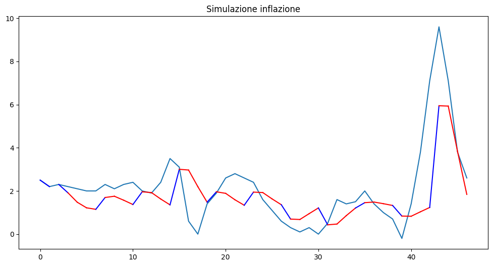

```python
#simulazione di passo t_interv

simulated_significant_inflation = eu_2000_2025['inflation'].copy().to_numpy()
excess_growth_dpi = eu_2000_2025['excess_dpi_gdp_growth'].to_numpy()
excess_broad_money = eu_2000_2025['excess_broad_money'].to_numpy()
excess_b_m_per_excess_dpi_gdp_growth=eu_2000_2025['excess_b_m_per_excess_dpi_gdp_growth'].to_numpy()
print(new)
excess_b_m_per_excess_dpi_gdp_growth[10:]=0
print(excess_b_m_per_excess_dpi_gdp_growth)

#cosa succede se i soldi restano nelle riserve? succede che in teoria non c'è inflazione, infatti creiamno dei dati in cui excress dpi è zero ad un certo , facciamo finta che nel 2020 col covid avessero solo stampato moneta
#excess_b_m_per_excess_dpi_gdp_growth=excess_growth_dpi*excess_broad_money
#excess_b_m_per_excess_dpi_gdp_growth[10:]=0


reg_significant = LinearRegression()
reg_significant.fit(X_significant, y)

t_interv=4
t_inizio_sim=2#23 #indice del 2013
t=t_inizio_sim
#plt.plot(excess_b_m_per_excess_dpi_gdp_growth)
simulated_significant_inflation[t+1:]=0




plt.figure(figsize=(12, 6))
plt.plot(np.arange(0,simulated_significant_inflation.size),eu_2000_2025['inflation'].copy().to_numpy())
plt.plot(np.arange(0,t),simulated_significant_inflation[0:t],color="blue")
while t<simulated_significant_inflation.size:
    j_final=t_interv
    color_plot='blue'
    if(t+j_final>=simulated_significant_inflation.size):
        j_final=(simulated_significant_inflation.size-t)-1

    for j in np.arange(1,j_final+1):

        if j==1:
            coef_0_2_inflation=reg_significant.coef_[0]*eu_2000_2025['inflation'].to_numpy()[t]+reg_significant.coef_[1]*eu_2000_2025['inflation'].to_numpy()[t-1]+reg_significant.coef_[2]*eu_2000_2025['inflation'].to_numpy()[t-2]
            coef_9_11_excess_b_m_per_excess_dpi_gdp_growth=reg.coef_[3]*excess_b_m_per_excess_dpi_gdp_growth[t-1]+reg.coef_[4]*excess_b_m_per_excess_dpi_gdp_growth[t-2]

        else:
            coef_0_2_inflation=reg_significant.coef_[0]*simulated_significant_inflation[t+j-1]+reg_significant.coef_[1]*simulated_significant_inflation[t+j-2]+reg_significant.coef_[2]*simulated_significant_inflation[t+j-3]
            coef_9_11_excess_b_m_per_excess_dpi_gdp_growth=reg.coef_[3]*excess_b_m_per_excess_dpi_gdp_growth[t+j-2]+reg.coef_[4]*excess_b_m_per_excess_dpi_gdp_growth[t+j-3]

            color_plot='red'
        simulated_significant_inflation[t+j] = reg_significant.intercept_ +  coef_0_2_inflation+coef_3_5_excess_growth_dpi+coef_6_8_excess_broad_money
        plt.plot([t+j-1,t+j],[simulated_significant_inflation[t+j-1],simulated_significant_inflation[t+j]],color=color_plot)#previsioni con dati aggiornati reali, rosso le prevesioni sugli ultimi dati dispnibili
    t=t+t_interv

plt.title("Simulazione inflazione")


#testing["simulated_significant_inflation"]=simulated_significant_inflation
#testing[["inflation","simulated_significant_inflation"]].plot()
```